# Question 20 from Time Series Homework 3

Question 20: In this problem, there is a way to do the problem using pencil-and-paper analysis, or you could even look up the answers in various time-series textbooks (paper or online). But, from my point of view, that would ruin the fun.

1. Construct a simulation to experimentally determine the variance (or Std.Dev.) of an AR(1) process at time 10 with parameter a_1=0.4 and sigma=7. Use y(0)=0.
2. Now try a wide variety of different sigma values. Make a record of your experiments. Describe the relationship between sigma or sigma^2 and Var(y(10)) or SD(y(10)), ideally using a formula.
3. Now set sigma=7 and try a wide variety of a_1 values. Make a record of your experiments. Describe the relationship between a_1 and Var(y(10)) or SD(y(10)).
4. Does y(100) or y(1000) behave differently than y(10) ?
5. -optional and hard- Now consider an AR(2) process. How does Var(y(1000)) vary with a_1 and a_2 ? Make a record of your experiments.

Start of Homework

```r
generate_AR1_process = function(y_1, a_1, sigma, size) {
  vector = 1:size
  vector[1] = 0
  for (i in 2:size) {
    vector[i] = a_1 * vector[i - 1] + sigma * rnorm(1, mean = 0, sd = 1)
  }
  return(vector)
}
```

The following block shows a line plot of the AR(1) process

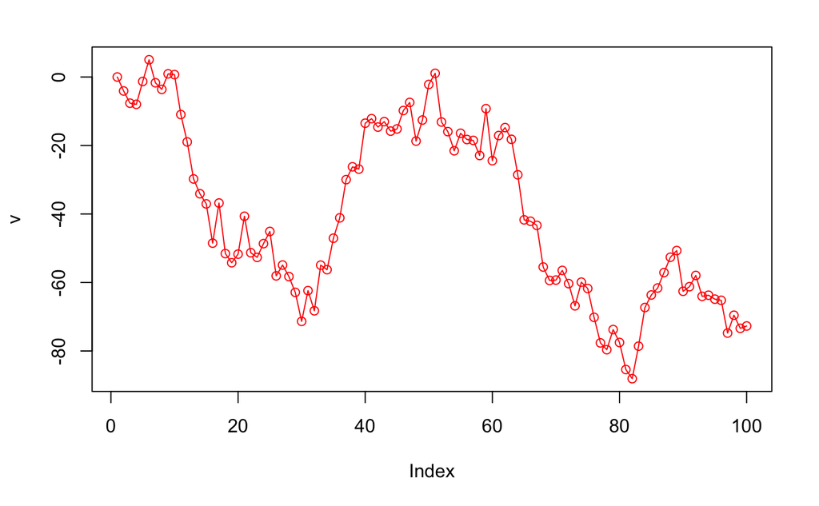

```r
y_1 = 0
a_1 = 1.0
sigma = 7.0
size = 100
v = generate_AR1_process(y_1 = y_1, a_1 = a_1, sigma = sigma, size = size)
plot(v,type = "o", col = "red")
```

1. Construct a simulation to experimentally determine the variance (or Std.Dev.) of an AR(1) process at time 10 with parameter a_1=0.4 and sigma=7. Use y(0)=0.

```r
make_samples_of_y_n = function(y_1, a_1, sigma, size, iterations) {
  samples_of_y_n = sapply(1:ITERATIONS,
                         function(x) generate_AR1_process(y_1 = y_1, a_1 = a_1, sigma = sigma, size = size)[size])
  return(samples_of_y_n)
}
y_1 = 0
a_1 = 1.0
sigma = 7.0
size = 10
ITERATIONS = 100
samples_of_y_10 = make_samples_of_y_n(y_1 = y_1, a_1 = a_1, sigma = sigma,
                                       size = size, iterations = ITERATIONS)
variance_of_samples = var(samples_of_y_10)
stdev_of_samples = sd(samples_of_y_10)
print(sprintf("variance of samples of y_%d: %5.3f", size, variance_of_samples))
```

```
[1] "variance of samples of y_10: 516.472"
```

```r
print(sprintf("stdev of samples of y_%d: %5.3f", size, stdev_of_samples))
```

```
[1] "stdev of samples of y_10: 22.726"
```

2. Now try a wide variety of different sigma values. Make a record of your experiments. Describe the relationship between sigma or sigma^2 and Var(y(10)) or SD(y(10)), ideally using a formula.

```r
y_1 = 0
a_1 = 1.0
size = 10
sigmas = 1:20 # <- note that this is a range !! =)
ITERATIONS = 100
#calculates a range of varianes corresponding to the sigma range 1:10
the_variances_of_samples = sapply(sigmas,
                                  function(sig) var(make_samples_of_y_n(y_1 = y_1,
                                                                         a_1 = a_1,
                                                                         sigma = sig,
                                                                         size = size,
                                                                         iterations = ITERATIONS)))
variance_output= "the variances (sigma: var): "
variance_output_result = sprintf("(sigma: %2d, var: %5.2f)\n", sigmas, the_variances_of_samples)
variance_output= cat(variance_output, "\n", variance_output_result)
```

```
the variances (sigma: var):
 (sigma:  1, var:  5.48)
 (sigma:  2, var: 34.69)
 (sigma:  3, var: 77.06)
 (sigma:  4, var: 155.14)
 (sigma:  5, var: 302.07)
 (sigma:  6, var: 306.06)
 (sigma:  7, var: 416.45)
 (sigma:  8, var: 604.46)
 (sigma:  9, var: 703.16)
 (sigma: 10, var: 831.22)
 (sigma: 11, var: 1126.01)
 (sigma: 12, var: 988.91)
 (sigma: 13, var: 1670.26)
 (sigma: 14, var: 2153.19)
 (sigma: 15, var: 2681.57)
 (sigma: 16, var: 2159.52)
 (sigma: 17, var: 2783.54)
 (sigma: 18, var: 2184.01)
 (sigma: 19, var: 3816.50)
 (sigma: 20, var: 3058.30)
```

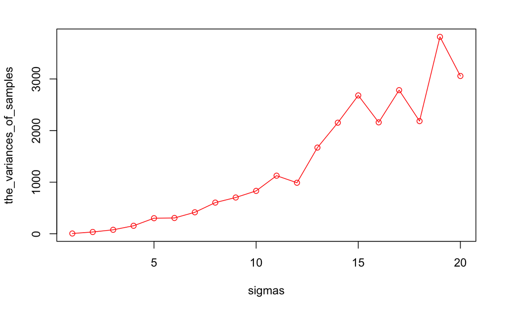

```r
plot(the_variances_of_samples, xlab="sigmas", type = "o", col = "red")
```

```r
#calculates a range of standard deviations corresponding to the sigma range 1:10
the_stdev_of_samples = sapply(sigmas,
                              function(sig) sd(make_samples_of_y_n(y_1 = y_1,
                                                                     a_1 = a_1,
                                                                     sigma = sig,
                                                                     size = size,
                                                                     iterations = ITERATIONS)))
stdev_output= "the stdevs (sigma: stdev): "
stdev_output_result = sprintf("(sigma: %2d, var: %5.2f)\n", sigmas, the_stdev_of_samples)
stdev_output= cat(stdev_output, "\n", stdev_output_result)
```

```
the stdevs (sigma: stdev):
 (sigma:  1, var:  2.66)
 (sigma:  2, var:  6.08)
 (sigma:  3, var:  8.57)
 (sigma:  4, var: 11.39)
 (sigma:  5, var: 16.08)
 (sigma:  6, var: 17.17)
 (sigma:  7, var: 19.14)
 (sigma:  8, var: 24.46)
 (sigma:  9, var: 23.61)
 (sigma: 10, var: 25.56)
 (sigma: 11, var: 36.94)
 (sigma: 12, var: 32.03)
 (sigma: 13, var: 35.94)
 (sigma: 14, var: 44.99)
 (sigma: 15, var: 42.25)
 (sigma: 16, var: 47.72)
 (sigma: 17, var: 52.99)
 (sigma: 18, var: 52.11)
 (sigma: 19, var: 55.56)
 (sigma: 20, var: 56.29)
```

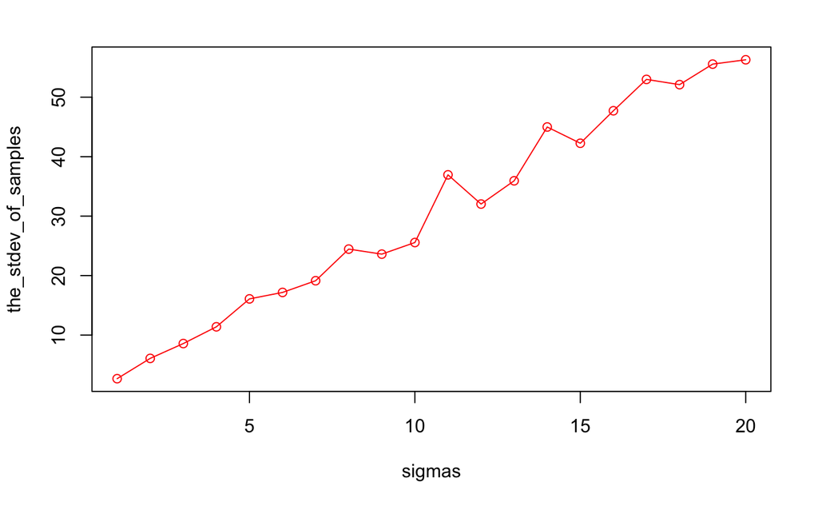

```r
plot(the_stdev_of_samples, xlab="sigmas", type = "o", col = "red")
```

3. Now set sigma=7 and try a wide variety of a_1 values. Make a record of your experiments. Describe the relationship between a_1 and Var(y(10)) or SD(y(10)).

```r
y_1 = 0
a_1s = seq(from = 0.1, to = 2.0, by = .1)
size = 10
sigmas = 7
ITERATIONS = 100
the_variances_of_samples = sapply(a_1s,
                                  function(a_1) var(make_samples_of_y_n(y_1 = y_1,
                                                                         a_1 = a_1,
                                                                         sigma = sigma,
                                                                         size = size,
                                                                         iterations = ITERATIONS)))
variance_output= "the variances (a_1: var): "
variance_output_result = sprintf("(a_1: %3.2f, var: %5.2f)\n", a_1s, the_variances_of_samples)
variance_output= cat(variance_output, "\n", variance_output_result)
```

```
the variances (a_1: var):
 (a_1: 0.10, var: 58.65)
 (a_1: 0.20, var: 62.28)
 (a_1: 0.30, var: 57.11)
 (a_1: 0.40, var: 49.16)
 (a_1: 0.50, var: 66.58)
 (a_1: 0.60, var: 74.41)
 (a_1: 0.70, var: 102.22)
 (a_1: 0.80, var: 154.13)
 (a_1: 0.90, var: 269.20)
 (a_1: 1.00, var: 490.74)
 (a_1: 1.10, var: 1203.65)
 (a_1: 1.20, var: 3049.82)
 (a_1: 1.30, var: 7804.51)
 (a_1: 1.40, var: 23272.00)
 (a_1: 1.50, var: 65605.62)
 (a_1: 1.60, var: 122117.35)
 (a_1: 1.70, var: 376444.17)
 (a_1: 1.80, var: 671735.87)
 (a_1: 1.90, var: 1911048.52)
 (a_1: 2.00, var: 4591314.80)
```

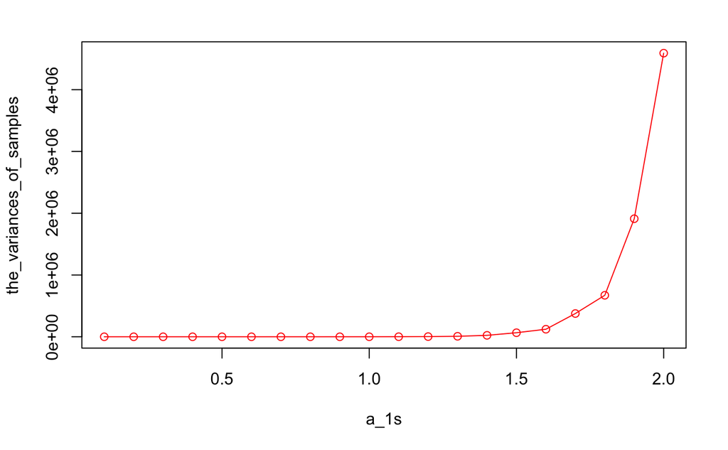

```r
plot(a_1s,the_variances_of_samples, xlab="a_1s", type = "o", col = "red")
```

```r
#calculates a range of standard deviations corresponding to the sigma range 1:10
the_stdev_of_samples = sapply(a_1s,
                              function(a_1) sd(make_samples_of_y_n(y_1 = y_1,
                                                                     a_1 = a_1,
                                                                     sigma = sigma,
                                                                     size = size,
                                                                     iterations = ITERATIONS)))
stdev_output= "the stdevs (a_1: stdev): "
stdev_output_result = sprintf("(a_1: %3.2f, var: %5.2f)\n", a_1s, the_stdev_of_samples)
stdev_output= cat(stdev_output, "\n", stdev_output_result)
```

```
the stdevs (a_1: stdev):
 (a_1: 0.10, var:  7.86)
 (a_1: 0.20, var:  7.58)
 (a_1: 0.30, var:  7.57)
 (a_1: 0.40, var:  7.32)
 (a_1: 0.50, var:  7.86)
 (a_1: 0.60, var:  8.69)
 (a_1: 0.70, var:  9.03)
 (a_1: 0.80, var: 10.62)
 (a_1: 0.90, var: 15.68)
 (a_1: 1.00, var: 18.48)
 (a_1: 1.10, var: 30.54)
 (a_1: 1.20, var: 54.79)
 (a_1: 1.30, var: 88.42)
 (a_1: 1.40, var: 141.99)
 (a_1: 1.50, var: 224.37)
 (a_1: 1.60, var: 379.66)
 (a_1: 1.70, var: 551.52)
 (a_1: 1.80, var: 906.34)
 (a_1: 1.90, var: 1402.98)
 (a_1: 2.00, var: 2028.41)
```

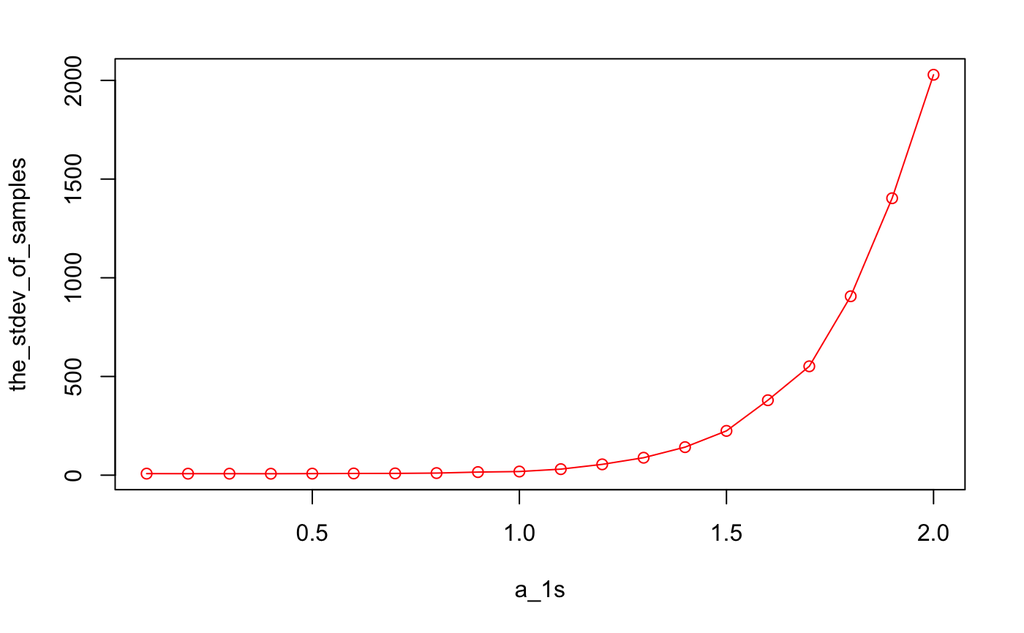

```r
plot(a_1s, the_stdev_of_samples, xlab="a_1s", type = "o", col = "red")
```

Observation: as a_1 increases, the standard deviation and variance of the sample y_10s grow with exponential or polynomial growth (i.e. x^2).

– iv) Does y(100) or y(1000) behave differently than y(10) ?

I calculated the variance and stdevs for y_10, y_100, and y_100 using the code block for answer (i)

for y_10 [1] “variance of samples of y_10: 470.086” [1] “stdev of samples of y_10: 21.681”

for y_100 [1] “variance of samples of y_100: 5082.061” [1] “stdev of samples of y_100: 71.289”

for y_1000 [1] “variance of samples of y_1000: 45840.570” [1] “stdev of samples of y_1000: 214.104”

I tried plotting the variance and stdev for y_100, y_1000 with the sigmas from 1:20. The standard deviations and variances increased in value but the trend in the increase was the same.

I also tried plotting the variance and stdevs for y_100, y_100 with a_1s ranging from .1 to 2.0. The stdevs and variances are much greater for higher values of y. The trend in growth seems to be the same for y_1 - y_10. The growth looks exponential or polynomial (x^2)

I would say no, y_100 and y_1000 do not behave differently than y_10.

22. -optional and hard- Now consider an AR(2) process. How does Var(y(1000)) vary with a_1 and a_2 ? Make a record of your experiments.